# Data annotation of *Epichloe amarillans* and *bromicola* genes

Imogen Dumville

27/02/2020

**Document purpose** This R markdown document describes production of datasets for *Epichloe amarillans* and *bromicola* species.

1. Lineage specific genes (LSG) are isolated as potenital sources of lineage-specific evolutoon, formation of new genes or increased evoltuionary rate.
2. The length of proteins produced is isolated. If LSG are much shorter than non-lineage speciifc genes they may be ‘new’ genes.
3. The distnace of LSG to the nearest ATrich repeat region is measured to determine potential of gene production.
4. Quantification of genes is carried out in datasets with RNAseq data ( *amarillans* ) to determine expression of LSG.
5. Gene ID, lineage specificity, length, TPM, and distance to AT regions is tabulated.
6. GO functional annotation of LSG is carried out and displayed in a seperate table to confer potential functions of new or altered genes.
7. Data is statsitically and graphically analysed.
8. This project has huge opportunity for further study.

**Making lineage specific gene datasets.** *amarillans* shown.

```r
orthos <- read.table("ortho_long.tsv", stringsAsFactors=FALSE, col.names=c("ortho_id", "gene_id", "strain")) #load dataset
# convert to named list, with strains represented by each ortho
by_ortho <- tapply(orthos$strain, orthos$ortho_id, FUN=unique)

strains <- unique(orthos$strain)

#fxn to find orthos with only one set of IDs
lineage_specific <- function(ortho_set, lineage_ids){
  all(ortho_set %in% lineage_ids) & length(ortho_set) == length(lineage_ids)
}

# which indices in by_ortho are amarillans speific.
all_amarillans <- sapply(by_ortho, lineage_specific, c("EamaE4668", "Eam702", "EamaE57")) #all amarillans clade

long_amarillans <- sapply(by_ortho, lineage_specific, c("Eam702")) #just long read
trueamaog <- data.frame(which(long_amarillans == TRUE))
colnames(trueamaog) <- "num"
amaorthonum <- by_ortho[trueamaog$num]
amaorthos <- data.frame(names(amaorthonum))

amageneID <- orthos[c(which(orthos$ortho_id %in% amaorthos$names.amaorthonum.)),]
write.table(amageneID$gene_id, file = "amarillansuniquegeneid.tsv", row.names = FALSE, col.names = FALSE, quote = FALSE)
```

There were 142 genes shared by all *amarillans* and no other clades There were 302 genes in Eam702 and no other strains

There were 32 genes shared by all *bromicola* and no other clades There are 394 genes in long read *bromicola* genome not found in any other strains

Dataset is produced from Eam702 and EbroNfe1 as these are long read genomes. Head of unqiue amarillans tsv is shown

```
##   Eam702_000028.T1
## 1 Eam702_000039-T1
## 2 Eam702_000046-T1
## 3 Eam702_000048-T1
## 4 Eam702_000086-T1
## 5 Eam702_000091-T1
## 6 Eam702_000104-T1
```

**Quantification of *amarillans* genes is carried out using RNAseq data.** This was carried out in shell, using Salmon. File; Eamquant.sf; is produced. For more information see https://github.com/Imogen-D/Cyclic-Peptide-Expression

salmon index -t <transcripts.fa> -i transcripts_index -k 31 salmon quant -i transcripts_index -l A -r reads.fq –validateMappings -p 8 -o transcripts_quant scp transcripts_quant/quant.sf ./quant.sf

**Calculation of distance to AT rich repeat regions** This is carried out in shell, using bedtools. gff files are supplied with locations of AT regions.

bedtools closest -d -a Epichloe_amarillans.gff3 -b Eam_AT_rich.gff | grep “gene” | cut -f9,18 > closest_AT.tsv

**Functional Annotation** To gain functional annotation, protein files from Eam702 and EbroNfe1 were uploaded to http://ekhidna2.biocenter.helsinki.fi/sanspanz/. This returned a dataset of GO annotations, titled AmarillansAnnoout.txt and BromicolaAnnoout.txt respectively. They were read into R to undergo GO enrichment, following code from https://github.com/dwinter/genome_factory/wiki/Taking-a-gene-list-and-PANNZER-output-through-to-GO-term-enrichment *amarillans* code shown, with *amarillans* and *bromicola* datasets displayed

```r
AmarillansAnnoout <- read.delim("~/CoxExtension/GO output/AmarillansAnnoout.txt", stringsAsFactors=FALSE, na.strings = "n.d.")

subsetammaGO <- AmarillansAnnoout[which(AmarillansAnnoout$PPV >= 0.5), c(1, 5)]

go_filt <- AmarillansAnnoout[which(AmarillansAnnoout$PPV >= 0.5),]
go_filt$id <- paste0('GO:', go_filt$id)
panzer_to_golist <- function(panzer_df){
  go_df <- aggregate( id ~ qpid, data=panzer_df, FUN=c)
  structure(go_df$id, .Names=go_df$qpid)
}
all_golist <- panzer_to_golist(go_filt)


make_topGO_DO <- function(gene_list, ontology, gene2GO_list){
  topGO_data <- new("topGOdata", ontology = ontology, allGenes = gene_list,
                    annot = annFUN.gene2GO, gene2GO = gene2GO_list)
  fishers_result <- runTest(topGO_data, algorithm = "elim", statistic = "fisher")
  fishers_table <- GenTable(topGO_data, Fishers = fishers_result, useLevels = TRUE)
  fishers_table$Ontology <- ontology
  fishers_table
}

amarillansuniquegeneid <- read.table("~/CoxExtension/LineageSpecificity/amarillansuniquegeneid.tsv", quote="\"", comment.char="", stringsAsFactors=FALSE)
ortho_long <- read.delim("~/CoxExtension/ortho_long.tsv", header=FALSE, stringsAsFactors=FALSE)
Eam702 <- ortho_long[which(ortho_long$V3 == "Eam702"),]
uniquegenes <- amarillansuniquegeneid$V1
geneList <- factor(as.integer(Eam702$V2 %in% uniquegenes))
names(geneList) <- Eam702$V2


topGO_BP_table <- make_topGO_DO(geneList, "BP", all_golist)
topGO_MF_table <- make_topGO_DO(geneList, "MF", all_golist)
topGO_CC_table <- make_topGO_DO(geneList, "CC", all_golist)

topGO_all_table <- (rbind(topGO_BP_table, topGO_MF_table, topGO_CC_table))
topGO_all_table <- topGO_all_table[order(topGO_all_table$Fishers),]

write.csv(topGO_all_table, file = "topGOfull.csv", quote = FALSE)
head(topGO_all_table)
```

```
##         GO.ID                                        Term Level Annotated
## 11 GO:0030619                            U1 snRNA binding     7         2
## 1  GO:0006122 mitochondrial electron transport, ubiqui...    15         4
## 2  GO:0006030                    chitin metabolic process     7         6
## 21 GO:0005685                                    U1 snRNP    12         6
## 22 GO:0043189    H4/H2A histone acetyltransferase complex    15         8
## 12 GO:0008061                              chitin binding     4        11
##    Significant Expected Fishers Ontology
## 11           2     0.03 0.00019       MF
## 1            2     0.05  0.0010       BP
## 2            2     0.08  0.0025       BP
## 21           2     0.10  0.0040       CC
## 22           2     0.14  0.0073       CC
## 12           2     0.15 0.00942       MF
```

Genes included relate to chitin porduction, a key influencer in the interaction of *Epichloe* and grass. They also include key componenets in RNA splicing and may relate to alternative splicing sites.

```
##        GO.ID                                        Term Level Annotated
## 2 GO:0006334                         nucleosome assembly     9        12
## 3 GO:0048846    axon extension involved in axon guidance    15         1
## 4 GO:0033615 mitochondrial proton-transporting ATP sy...     9         1
## 5 GO:0034723 DNA replication-dependent nucleosome org...     8         1
## 6 GO:0071711              basement membrane organization     6         1
## 7 GO:0000395             mRNA 5'-splice site recognition    15         1
##   Significant Expected Fishers Ontology
## 2           2     0.12  0.0060       BP
## 3           1     0.01  0.0099       BP
## 4           1     0.01  0.0099       BP
## 5           1     0.01  0.0099       BP
## 6           1     0.01  0.0099       BP
## 7           1     0.01  0.0099       BP
```

*bromicola* genes are also related to key cellular functions. There is one related to RNA-directed DNA Polymerase activity: EbroNfe1_002229-T1, MF_ARGOT, 7.7824356421, 0.7097647, GO:0003964, RNA-directed DNA polymerase activity

**Code to produce dataset of *amarillans* Information**

Create csv containing information on length, distance to AT, TPM and lineage specificity

```r
ortho_long <- read.delim("~/CoxExtension/ortho_long.tsv", header=FALSE, stringsAsFactors=FALSE) #load ortholog file
Eamquant <- read.delim("~/CoxExtension/RNA/quantfiles/Eamquant.sf", stringsAsFactors=FALSE) #load quant file
amarillansuniquegeneid <- read.table("~/CoxExtension/LineageSpecificity/amarillansuniquegeneid.tsv", quote="\"", comment.char="", stringsAsFactors=FALSE) #load list of lineage specific genes

Eam702 <- ortho_long[which(ortho_long$V3 == "Eam702"),] #subsetting
colnames(Eam702) <- c("ortholog", "Name", "Strain") #renaming for merging
mergedTPMandid <- merge(Eam702, Eamquant) #first merge

uniquegenes <- amarillansuniquegeneid$V1 #subsetting
geneList <- factor(as.integer(Eam702$Name %in% uniquegenes))
names(geneList) <- Eam702$Name
TFgenes <- data.frame(TF = geneList, Name = Eam702$Name, row.names = NULL)
mergedTPMandTF <- merge(mergedTPMandid, TFgenes)

Amaclosest_AT <- read.delim("~/CoxExtension/Amaclosest_AT.tsv", header=FALSE, stringsAsFactors=FALSE)
Amaclosest_AT$V1 <- str_remove(Amaclosest_AT$V1, "ID=")
Amaclosest_AT$V1 <- str_replace(Amaclosest_AT$V1, ";", "-T1")
colnames(Amaclosest_AT) <- c("Name", "DistanceAT")

Amarillansfinalframe <- merge(Amaclosest_AT, mergedTPMandTF)

Amarillansfinalframe$TF <- str_replace(Amarillansfinalframe$TF, "0", "FALSE")
Amarillansfinalframe$TF <- str_replace(Amarillansfinalframe$TF, "1", "TRUE")

write.csv(Amarillansfinalframe, file = "AmarillansData.csv")

head(Amarillansfinalframe)
```

```
##               Name DistanceAT ortholog Strain Length EffectiveLength        TPM
## 1 Eam702_000001-T1      63298  og_6853 Eam702   1971            1722   0.519836
## 2 Eam702_000002-T1          0  og_0644 Eam702    960             711  62.836155
## 3 Eam702_000003-T1        308  og_0157 Eam702    894             645 468.333379
## 4 Eam702_000004-T1      61144  og_7959 Eam702   1566            1317  34.479049
## 5 Eam702_000005-T1       1732  og_7542 Eam702    543             294  88.851458
## 6 Eam702_000006-T1        595  og_3582 Eam702   1257            1008  75.403795
##   NumReads    TF
## 1       11 FALSE
## 2      549 FALSE
## 3     3712 FALSE
## 4      558 FALSE
## 5      321 FALSE
## 6      934 FALSE
```

*bromicola* final frame code not shown, although some edits made from *amarillans* code. Due to a lack of RNAseq (and therefore quantification) data, no TPM is available. Length was caulcated manually utilising protein sequences and Bioawk, before being read into R and appended to dataset. Head of *bromicola* frame is shown.

```
##                 Name DistanceAT ortholog   Strain    TF Length
## 1 EbroNfe1_000001-T1       1403  og_4422 EbroNfe1 FALSE    259
## 2 EbroNfe1_000002-T1        798  og_5274 EbroNfe1 FALSE    330
## 3 EbroNfe1_000003-T1       3767  og_1293 EbroNfe1 FALSE    163
## 4 EbroNfe1_000004-T1       5046  og_0409 EbroNfe1 FALSE    341
## 5 EbroNfe1_000005-T1       1690 og_29412 EbroNfe1  TRUE    213
## 6 EbroNfe1_000006-T1        113  og_7009 EbroNfe1 FALSE    148
```

**Graphical representation** Boxplots were produced for variables in comparison to lineage specificity

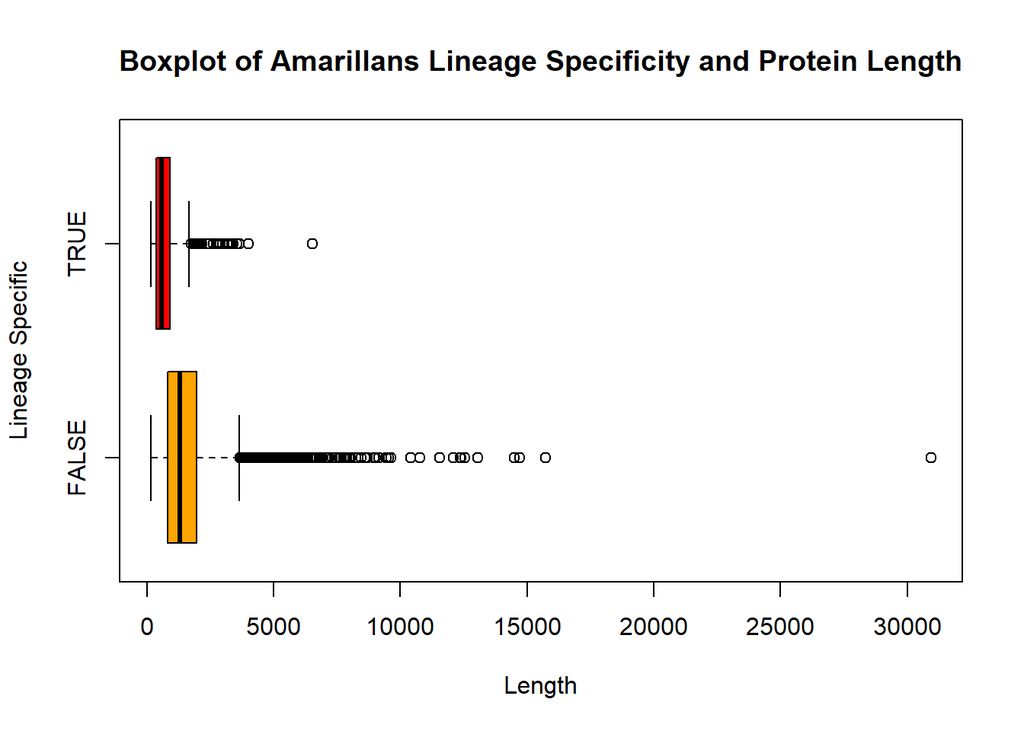

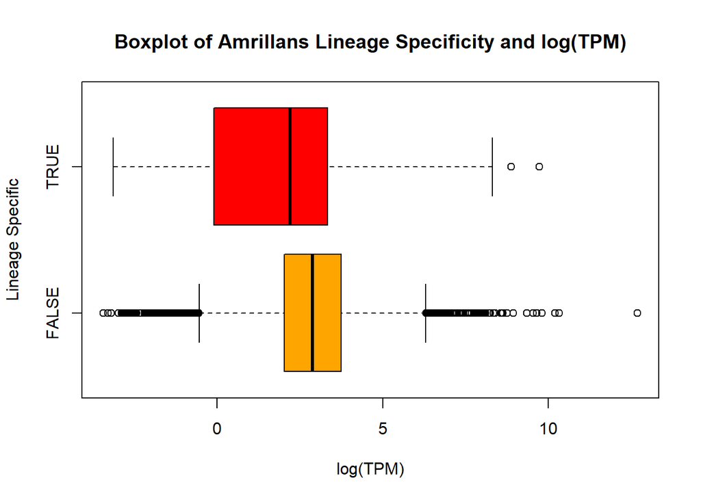

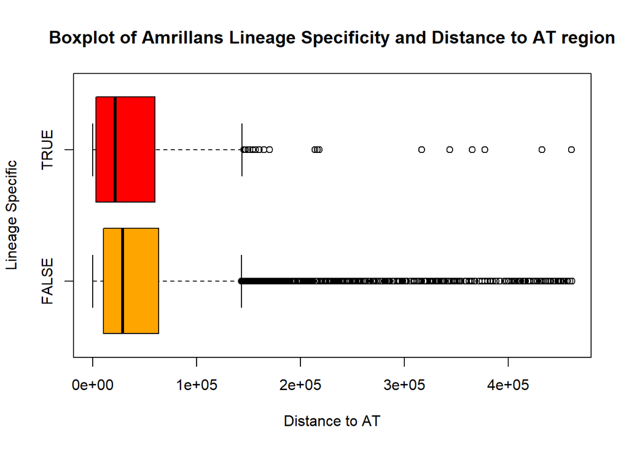

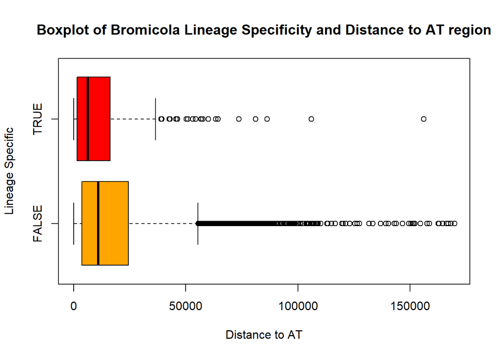

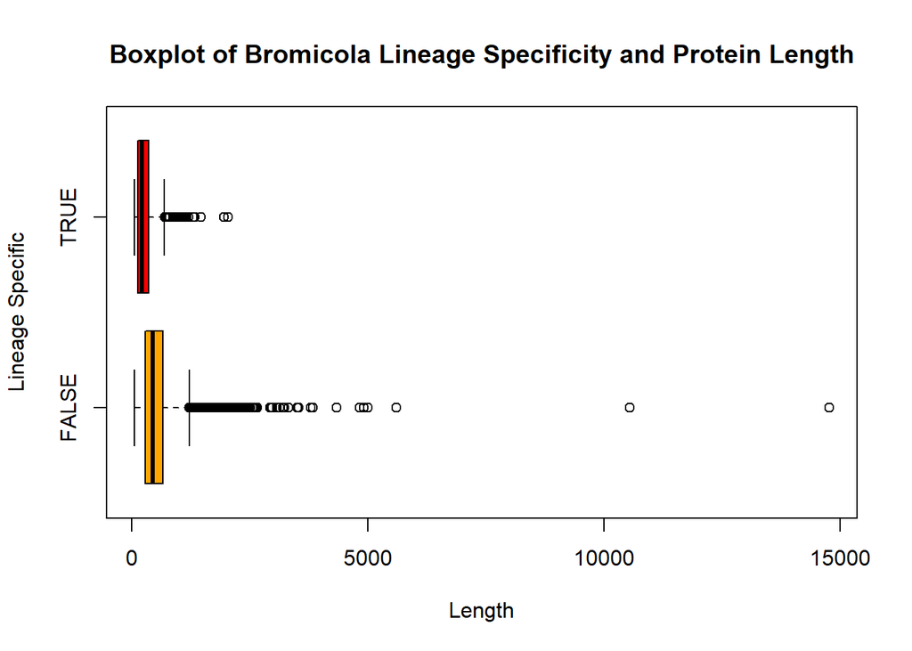

**Statistical Analysis** It can be observed that lineage specific genes appear to be shorter, closer to ATrich repeat regions and less expressed (the latter only shown in *amarillans*). Significance of these results was tested and all significant (below).

```
##
## Call:
## glm(formula = TPM < 2 ~ TF, family = "binomial", data = Amarillansfinalframe)
##
## Deviance Residuals:
##     Min       1Q   Median       3Q      Max
## -0.8468  -0.4399  -0.4399  -0.4399   2.1835
##
## Coefficients:
##             Estimate Std. Error z value Pr(>|z|)
## (Intercept) -2.28699    0.04088  -55.94   <2e-16 ***
## TFTRUE       1.44599    0.13191   10.96   <2e-16 ***
## ---
## Signif. codes:  0 '***' 0.001 '**' 0.01 '*' 0.05 '.' 0.1 ' ' 1
##
## (Dispersion parameter for binomial family taken to be 1)
##
##     Null deviance: 4865.5  on 7448  degrees of freedom
## Residual deviance: 4766.7  on 7447  degrees of freedom
## AIC: 4770.7
##
## Number of Fisher Scoring iterations: 5
```

```
##
## Call:
## glm(formula = DistanceAT < 2000 ~ TF, family = "binomial", data = Amarillansfinalframe)
##
## Deviance Residuals:
##     Min       1Q   Median       3Q      Max
## -0.7023  -0.4963  -0.4963  -0.4963   2.0763
##
## Coefficients:
##             Estimate Std. Error z value Pr(>|z|)
## (Intercept) -2.03230    0.03696 -54.988  < 2e-16 ***
## TFTRUE       0.75813    0.14407   5.262 1.42e-07 ***
## ---
## Signif. codes:  0 '***' 0.001 '**' 0.01 '*' 0.05 '.' 0.1 ' ' 1
##
## (Dispersion parameter for binomial family taken to be 1)
##
##     Null deviance: 5466.9  on 7448  degrees of freedom
## Residual deviance: 5442.7  on 7447  degrees of freedom
## AIC: 5446.7
##
## Number of Fisher Scoring iterations: 4
```

```
##
## Call:
## glm(formula = Length < 500 ~ TF, family = "binomial", data = Amarillansfinalframe)
##
## Deviance Residuals:
##     Min       1Q   Median       3Q      Max
## -1.0556  -0.4578  -0.4578  -0.4578   2.1484
##
## Coefficients:
##             Estimate Std. Error z value Pr(>|z|)
## (Intercept) -2.20299    0.03952  -55.75   <2e-16 ***
## TFTRUE       1.90951    0.12286   15.54   <2e-16 ***
## ---
## Signif. codes:  0 '***' 0.001 '**' 0.01 '*' 0.05 '.' 0.1 ' ' 1
##
## (Dispersion parameter for binomial family taken to be 1)
##
##     Null deviance: 5248.0  on 7448  degrees of freedom
## Residual deviance: 5042.7  on 7447  degrees of freedom
## AIC: 5046.7
##
## Number of Fisher Scoring iterations: 4
```

```
##
## Call:
## glm(formula = Length < 500 ~ TF, family = "binomial", data = BromicolaFinalFrame)
##
## Deviance Residuals:
##    Min      1Q  Median      3Q     Max
## -1.984  -1.316   1.044   1.044   1.044
##
## Coefficients:
##             Estimate Std. Error z value Pr(>|z|)
## (Intercept)  0.32097    0.02384   13.46   <2e-16 ***
## TFTRUE       1.49770    0.14731   10.17   <2e-16 ***
## ---
## Signif. codes:  0 '***' 0.001 '**' 0.01 '*' 0.05 '.' 0.1 ' ' 1
##
## (Dispersion parameter for binomial family taken to be 1)
##
##     Null deviance: 10285  on 7614  degrees of freedom
## Residual deviance: 10145  on 7613  degrees of freedom
## AIC: 10149
##
## Number of Fisher Scoring iterations: 4
```

```
##
## Call:
## glm(formula = DistanceAT < 2000 ~ TF, family = "binomial", data = BromicolaFinalFrame)
##
## Deviance Residuals:
##     Min       1Q   Median       3Q      Max
## -0.8265  -0.6106  -0.6106  -0.6106   1.8823
##
## Coefficients:
##             Estimate Std. Error z value Pr(>|z|)
## (Intercept) -1.58521    0.03132 -50.607  < 2e-16 ***
## TFTRUE       0.68661    0.11543   5.948 2.71e-09 ***
## ---
## Signif. codes:  0 '***' 0.001 '**' 0.01 '*' 0.05 '.' 0.1 ' ' 1
##
## (Dispersion parameter for binomial family taken to be 1)
##
##     Null deviance: 7091.5  on 7614  degrees of freedom
## Residual deviance: 7059.3  on 7613  degrees of freedom
## AIC: 7063.3
##
## Number of Fisher Scoring iterations: 4
```